# PCA Analysis on the example of data regarding US states

Piotr Wieczorek

2023-12-11

## Goal of the project

#### **This project aims to demonstrate whether or not US states that are governed by either democrat or republican politicians can be grouped and explained by following variables:**

1. homelessness_rate - homelessness per 100000 inhabitants in respective state
2. homicide_mortality_rate - homicide mortality per 100000 inhabitants in respective state
3. guns_ownership - number of guns owned by inhabitants in respective state
4. suicide_rate - number of suicide cases per 100000 inhabitants in respective state
5. rape_rate - number of rape cases per 100000 inhabitants in respective state

```r
rm(list=ls())
```

## Libraries

```r
library(factoextra)
library(tidyverse)
library(readxl)
library(janitor)
library(gridExtra)
```

## Loading and cleaning the data

```r
usa_gdp_per_capita <- read_excel("usa_gdp_per_capita.xlsx")
usa_gdp_per_capita <- janitor::clean_names(usa_gdp_per_capita)
```

```r
head(usa_gdp_per_capita)
```

```
## # A tibble: 6 × 2
##   state_or_federal_district nominal_gdp_pc
##   <chr>                     <chr>
## 1 California *              $92,190
## 2 Texas *                   $78,456
## 3 New York *                $104,344
## 4 Florida *                 $62,446
## 5 Illinois *                $82,126
## 6 Pennsylvania *            $71,160
```

```r
usa_gdp_per_capita$state_or_federal_district <- sub("\\s*\\*", "",usa_gdp_per_capita$state_or_federal_district)
usa_gdp_per_capita$state_or_federal_district  <- str_trim(usa_gdp_per_capita$state_or_federal_district)
```

```r
usa_gdp_per_capita$nominal_gdp_pc <- str_replace(usa_gdp_per_capita$nominal_gdp_pc,",",".")
usa_gdp_per_capita$nominal_gdp_pc <- str_sub(usa_gdp_per_capita$nominal_gdp_pc,start = 2)
```

```r
usa_gdp_per_capita <- usa_gdp_per_capita %>%
  mutate(nominal_gdp_pc = as.numeric(nominal_gdp_pc))
```

```r
head(usa_gdp_per_capita)
```

```
## # A tibble: 6 × 2
##   state_or_federal_district nominal_gdp_pc
##   <chr>                              <dbl>
## 1 California                          92.2
## 2 Texas                               78.5
## 3 New York                           104.
## 4 Florida                             62.4
## 5 Illinois                            82.1
## 6 Pennsylvania                        71.2
```

```r
usa_drug_overdose <- read.csv("usa_drug_overdose.csv")
```

```r
usa_drug_overdose <- usa_drug_overdose %>%
  filter(YEAR==2021) %>%
  select(STATE,RATE) %>%
  mutate(RATE = as.numeric(RATE))
```

```r
usa_suicide <- read.csv("usa_suicide.csv")
```

```r
usa_suicide <- usa_suicide %>%
  filter(YEAR == 2021) %>%
  select(STATE,RATE) %>%
  mutate(RATE=as.numeric(RATE))
```

```r
usa_homicide_mortality <- read.csv("usa_homicide_mortality.csv")
```

```r
usa_homicide_mortality <- usa_homicide_mortality %>%
  filter(YEAR==2021) %>%
  select(STATE,RATE) %>%
  mutate(RATE = as.numeric(RATE))
```

```r
codes <- read_excel("us_states_code.xlsx")
```

```r
head(codes)
```

```
## # A tibble: 6 × 2
##   state      state_code
##   <chr>      <chr>
## 1 Alabama    AL
## 2 Alaska     AK
## 3 Arizona    AZ
## 4 Arkansas   AR
## 5 California CA
## 6 Colorado   CO
```

```r
usa_suicide <- inner_join(usa_suicide,codes,by = c("STATE"="state_code"))
usa_homicide_mortality <- inner_join(usa_homicide_mortality,codes,by=c("STATE"="state_code"))
usa_drug_overdose <- inner_join(usa_drug_overdose,codes,by=c("STATE"="state_code"))
```

```r
usa_drug_overdose <- usa_drug_overdose %>%
  select(-c("STATE"))

usa_homicide_mortality <- usa_homicide_mortality %>%
  select(-c("STATE"))

usa_suicide <- usa_suicide %>%
  select(-c("STATE"))

usa_suicide <- clean_names(usa_suicide)
usa_homicide_mortality <- clean_names(usa_homicide_mortality)
usa_drug_overdose <- clean_names(usa_drug_overdose)
usa_gdp_per_capita <- clean_names(usa_gdp_per_capita)
```

```r
colnames(usa_suicide)[1] <- "suicide_rate"
usa_suicide <- usa_suicide %>%
  arrange(state)

colnames(usa_homicide_mortality)[1] <- "homicide_mortality_rate"
usa_homicide_mortality <- usa_homicide_mortality %>%
  arrange(state)

colnames(usa_drug_overdose)[1] <- "drug_overdose_rate"
usa_drug_overdose <- usa_drug_overdose %>%
  arrange(state)

colnames(usa_gdp_per_capita)[1] <- "state"
usa_gdp_per_capita <- usa_gdp_per_capita %>%
  arrange(state)
```

```r
usa_governor <- read_excel("us_election_governor.xlsx")
```

```r
usa_governor <- usa_governor %>%
  select(c(1,3)) %>%
  arrange(State) %>%
  rename(state = "State") %>%
  rename(governor = "Governor")
```

```r
usa_guns <- read_excel("usa_guns.xlsx")
```

```r
usa_guns <- usa_guns %>%
  rename(state="State") %>%
  arrange(state)
```

```r
usa_homeless <- read_excel("usa_homelessness.xlsx")
```

```r
usa_homeless <- usa_homeless %>%
  rename(homelessness_rate = "homelessness") %>%
  arrange(state)
```

```r
usa_rape <- read_excel("usa_rape.xlsx")
```

```r
usa_rape <- usa_rape %>%
  rename(state="State") %>%
  arrange(state)
```

### Merging the data

```r
merged_df <- merge(usa_gdp_per_capita, usa_drug_overdose, by = "state", all.x = FALSE)

merged_df <- merge(merged_df, usa_homicide_mortality, by = "state", all.x = FALSE)

merged_df <- merge(merged_df, usa_suicide, by = "state", all.x = FALSE)

merged_df <- merge(merged_df,usa_governor,by="state",all.x=FALSE)

merged_df <- merge(merged_df, usa_guns,by="state",all.x=FALSE)

merged_df <- merge(merged_df, usa_homeless, by="state",all.x=FALSE)

merged_df <- merge(merged_df, usa_rape, by="state",all.x=FALSE)

print(merged_df)
```

```
##             state nominal_gdp_pc drug_overdose_rate homicide_mortality_rate
## 1         Alabama         54.753               30.1                    15.9
## 2          Alaska         86.722               35.6                     6.4
## 3         Arizona         62.365               38.7                     8.1
## 4        Arkansas         54.259               22.3                    11.7
## 5      California         92.190               26.6                     6.4
## 6        Colorado         82.954               31.4                     6.3
## 7     Connecticut         88.760               42.3                     4.8
## 8        Delaware         85.977               54.0                    11.3
## 9         Florida         62.446               37.5                     7.4
## 10        Georgia         69.253               23.5                    11.4
## 11         Hawaii         68.207               17.3                     2.7
## 12          Idaho         56.496               19.0                     2.2
## 13       Illinois         82.126               29.0                    12.3
## 14        Indiana         66.698               43.0                     9.6
```

[output cut: 87 more lines]

```r
merged_df$nominal_gdp_pc <- gsub("\\.", "", as.character(merged_df$nominal_gdp_pc))
merged_df$nominal_gdp_pc <- as.numeric(merged_df$nominal_gdp_pc)
```

```r
head(merged_df)
```

```
##        state nominal_gdp_pc drug_overdose_rate homicide_mortality_rate
## 1    Alabama          54753               30.1                    15.9
## 2     Alaska          86722               35.6                     6.4
## 3    Arizona          62365               38.7                     8.1
## 4   Arkansas          54259               22.3                    11.7
## 5 California           9219               26.6                     6.4
## 6   Colorado          82954               31.4                     6.3
##   suicide_rate   governor guns_ownership homelessness_rate rape_rate
## 1         15.8 Republican           3870               7.4      42.2
## 2         30.8 Republican           3850              31.7     148.7
## 3         19.5 Democratic           3560              18.6      50.3
## 4         20.6 Republican           4430               8.1      77.2
## 5         10.1 Democratic           1040              43.7      37.5
## 6         22.8 Democratic           2570              17.9      67.2
```

```r
row.names(merged_df) <- merged_df$state
```

```r
merged_df <- merged_df %>%
  select(-c("state"))
```

```r
merged_df <- merged_df %>%
  select(c("suicide_rate","rape_rate","guns_ownership","homelessness_rate","homicide_mortality_rate",
           "governor"))
```

## PCA Analysis

### Bartlett test of homogeneity of variances

```r
bartlett.test(x = merged_df %>% select_if(is.numeric), nrow(merged_df))
```

```
##
##  Bartlett test of homogeneity of variances
##
## data:  merged_df %>% select_if(is.numeric)
## Bartlett's K-squared = 1943.5, df = 4, p-value < 2.2e-16
```

```r
pca <- prcomp(merged_df[,1:5],scale. = TRUE)
```

### Dimensionality - cumulative variance proportion

```r
summary(pca)
```

```
## Importance of components:
##                           PC1    PC2    PC3    PC4     PC5
## Standard deviation     1.4105 1.1751 0.9459 0.7053 0.48726
## Proportion of Variance 0.3979 0.2762 0.1789 0.0995 0.04748
## Cumulative Proportion  0.3979 0.6741 0.8530 0.9525 1.00000
```

### Eigen vectors

```r
pca$rotation
```

```
##                                 PC1         PC2         PC3         PC4
## suicide_rate             0.65120700 -0.10387622  0.09614692 -0.06650191
## rape_rate                0.53771966  0.09480661  0.56778247  0.36054912
## guns_ownership           0.49071760 -0.30778702 -0.52811046 -0.43420528
## homelessness_rate        0.06602561  0.73870330  0.18976682 -0.64234147
## homicide_mortality_rate -0.20401927 -0.58292883  0.59453068 -0.51424220
##                                 PC5
## suicide_rate            -0.74261190
## rape_rate                0.49949642
## guns_ownership           0.44387893
## homelessness_rate        0.03666122
## homicide_mortality_rate  0.02565815
```

### Correlation between pca scores and numerical data from merged_df

```r
pca_scores <- pca$x[,c("PC1","PC2")]
```

### Correlation between numerical variables and pca scores

#### Based on the correlations:

- if suicide_rate increases, PCA1 strongly increases and PC2 slightly decreases
- if rape_rate increases, PCA1 increases strongly and PC2 increases slightly
- if guns_ownership increases, PC1 increases strongly and PC2 decreases
- if homelessness_rate increases, it has a slight positive effect on PC1, PC2 strongly increases
- if homicide_mortality_rate increases, PC1 slightly decreases and PC2 strongly decreases

```r
cor(merged_df[,1:5],pca_scores)
```

```
##                                 PC1        PC2
## suicide_rate             0.91853029 -0.1220660
## rape_rate                0.75845591  0.1114082
## guns_ownership           0.69215930 -0.3616836
## homelessness_rate        0.09312941  0.8680575
## homicide_mortality_rate -0.28777006 -0.6850054
```

### Scree plot

#### Overall, Dim1 and Dim2 capture 67% of variance

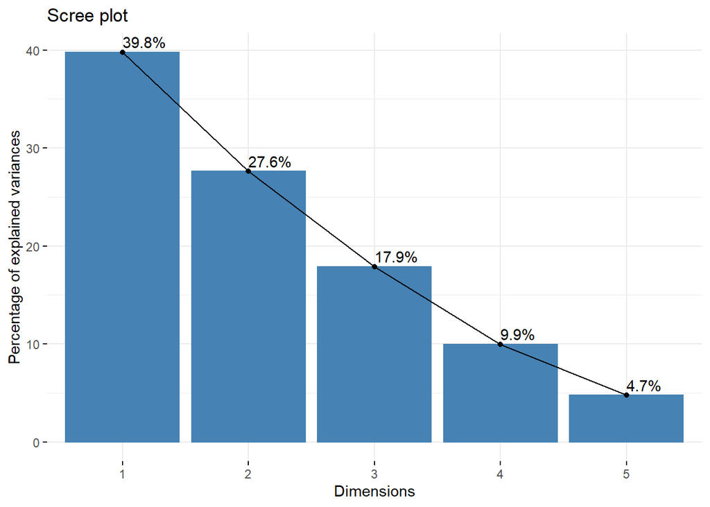

```r
fviz_eig(pca,addlabels = TRUE)
```

### Variables contribution to Dim1

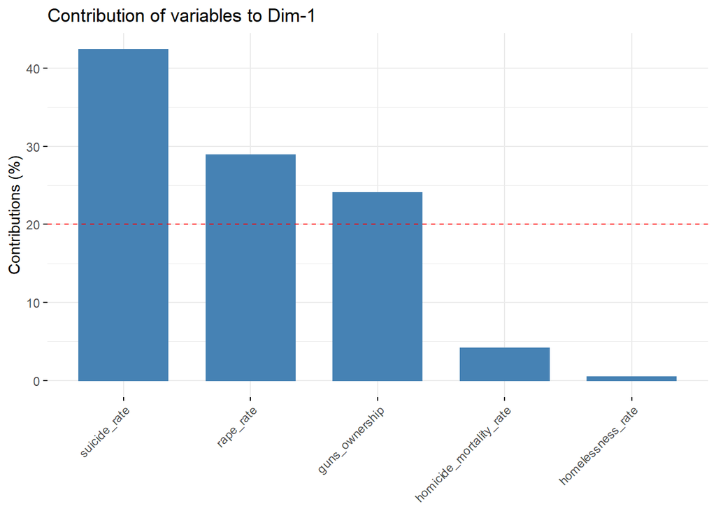

```r
fviz_contrib(pca,choice="var")
```

### Variables contribution to Dim2

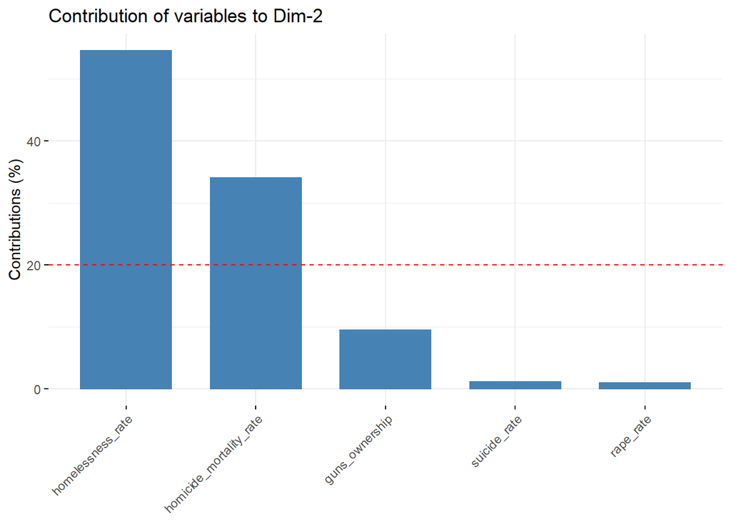

```r
fviz_contrib(pca,choice="var",axes=2)
```

### PCA Plot

#### Based on the PCA Plot:

1. Variables that are positively correlated: rape_rate, suicide_rate, guns_ownership
2. Variables that are negatively correlated: homelessness_rate and homicide_mortality_rate

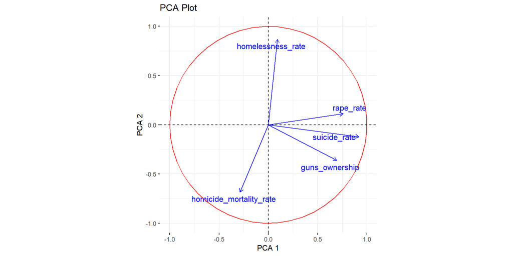

```r
fviz_pca_var(pca,
             repel = TRUE,
             col.circle = "red",
             col.var="blue")+
  labs(title = "PCA Plot",
       x = "PCA 1",
       y = "PCA 2")
```